# 03_Predictive_Analysis

## Predictive Modelling (LREE)

### Random Forest Model: Option 1 (All elements from ME-4ACD81)

Combination of All elements from ME-4ACD81 in predicting LREE.

#### Data Preparation

```r
# Filter the training and test datasets to include predictors and target variables only
DT_lree_train_fltr <- DT_lree_train[,c("LREE","Ag", "Cd", "Co", "Cu", "Li", "Mo", "Ni", "Pb", "Sc", "Tl", "Zn")]
DT_lree_test_fltr <- DT_lree_test[,c("LREE","Ag", "Cd", "Co", "Cu", "Li", "Mo", "Ni", "Pb", "Sc", "Tl", "Zn")]

# Create a cross-validation data for resampling purposes during hyperparameter tuning
set.seed(2022)
DT_lree_fltr_folds <- vfold_cv(DT_lree_train_fltr, v = 5, repeats = 2)
```

#### Build the Model

```r
# Create a recipe for preprocessing
rf_lree_recipe <- recipe(LREE ~ ., data = DT_lree_train_fltr)

# Create a workflow
rf_lree_tuned_workflow <- workflow() %>%
  add_recipe(rf_lree_recipe) %>%
  add_model(rf_tuned_spec)

# Set-up the hyperparameter tuning
rf_lree_tuned_grid <- grid_regular(
  mtry(range = c(1,11)),
  min_n(),
  trees(),
  levels = 5)

# Perform the hyperparameter tuning search
set.seed(2022)
rf_lree_random_tune <- tune_grid(
  rf_lree_tuned_workflow,
  resamples = DT_lree_fltr_folds,
  grid = rf_lree_tuned_grid,
  metrics = metric_set(rmse, rsq, mae)
)

# Show the best configurations
show_best(rf_lree_random_tune, n = 3)
```

```
## # A tibble: 3 × 9
##    mtry trees min_n .metric .estimator  mean     n std_err .config
##   <int> <int> <int> <chr>   <chr>      <dbl> <int>   <dbl> <chr>
## 1    11  1000     2 rmse    standard    47.5    10    6.17 Preprocessor1_Model0…
## 2     8  1000    11 rmse    standard    47.6    10    6.45 Preprocessor1_Model0…
## 3     8  1500     2 rmse    standard    47.6    10    6.37 Preprocessor1_Model0…
```

```r
# Fit the best model into the training set
set.seed(2022)
rf_lree_random_tuned_fit <- finalize_workflow(rf_lree_tuned_workflow, select_best(rf_lree_random_tune)) %>%
    fit(DT_lree_train_fltr)
# Apply the trained recipe to the testing data
# 'bake()' will apply all recipe steps (e.g., imputation, normalization) to the testing dataset
DT_train_lree_fltr_prep <- bake(prep(rf_lree_recipe), new_data = DT_lree_train_fltr)
DT_test_lree_fltr_prep <- bake(prep(rf_lree_recipe), new_data = DT_lree_test_fltr)

# Make predictions on the preprocessed testing data
rf_lree_tr_rdm_tuned_pred <- predict(rf_lree_random_tuned_fit, new_data = DT_lree_train_fltr)
rf_lree_ts_rdm_tuned_pred <- predict(rf_lree_random_tuned_fit, new_data = DT_lree_test_fltr)
```

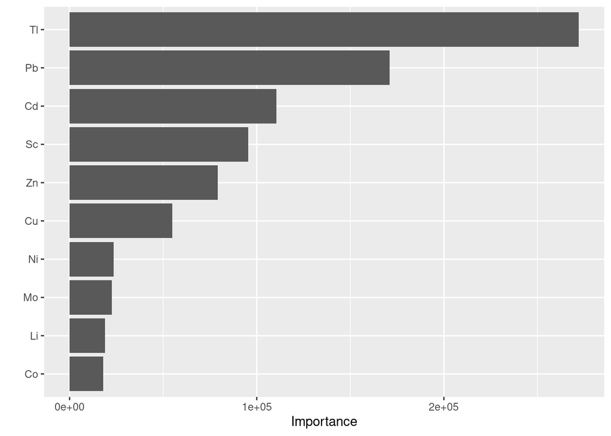

```r
# Plot variable importance
rf_lree_random_tuned_fit %>%
  extract_fit_parsnip() %>%
  vip::vip()
```

#### Evaluate the Model

```r
# RF Tuned Results for all elements from ME-4ACD81
## Training set evaluation
results_train_rf_lree_rdm_tuned <- rf_lree_tr_rdm_tuned_pred %>%
  bind_cols(DT_lree_train_fltr) %>%
  dplyr::select(.pred, LREE) %>%
  rename(truth = LREE) %>%
  mutate(model = "RF_Rdm_Tuned_LREE")

## Test set evaluation
results_test_rf_lree_rdm_tuned <- rf_lree_ts_rdm_tuned_pred %>%
  bind_cols(DT_lree_test_fltr) %>%
  dplyr::select(.pred, LREE) %>%
  rename(truth = LREE) %>%
  mutate(model = "RF_Rdm_Tuned_LREE")

# Merge the results
## Training set
results_lree_train <- results_train_rf_lree_rdm_tuned

## Test set
results_lree_test <- results_test_rf_lree_rdm_tuned

# Show the evaluation metrics for every model
## Training set
results_lree_train %>%
  group_by(model) %>%
  summarise(RMSE = RMSE(.pred, truth),
            R_Square = R2_Score(.pred, truth),
            MAE = MAE(.pred, truth),
            MAPE = MAPE(.pred, truth))
```

```
## # A tibble: 1 × 5
##   model              RMSE R_Square   MAE  MAPE
##   <chr>             <dbl>    <dbl> <dbl> <dbl>
## 1 RF_Rdm_Tuned_LREE  18.6    0.937  12.0 0.135
```

```r
## Test set
results_lree_test %>%
  group_by(model) %>%
  summarise(RMSE = RMSE(.pred, truth),
            R_Square = R2_Score(.pred, truth),
            MAE = MAE(.pred, truth),
            MAPE = MAPE(.pred, truth))
```

```
## # A tibble: 1 × 5
##   model              RMSE R_Square   MAE  MAPE
##   <chr>             <dbl>    <dbl> <dbl> <dbl>
## 1 RF_Rdm_Tuned_LREE  39.6    0.610  26.6 0.251
```

#### Prediction vs Actual Comparison

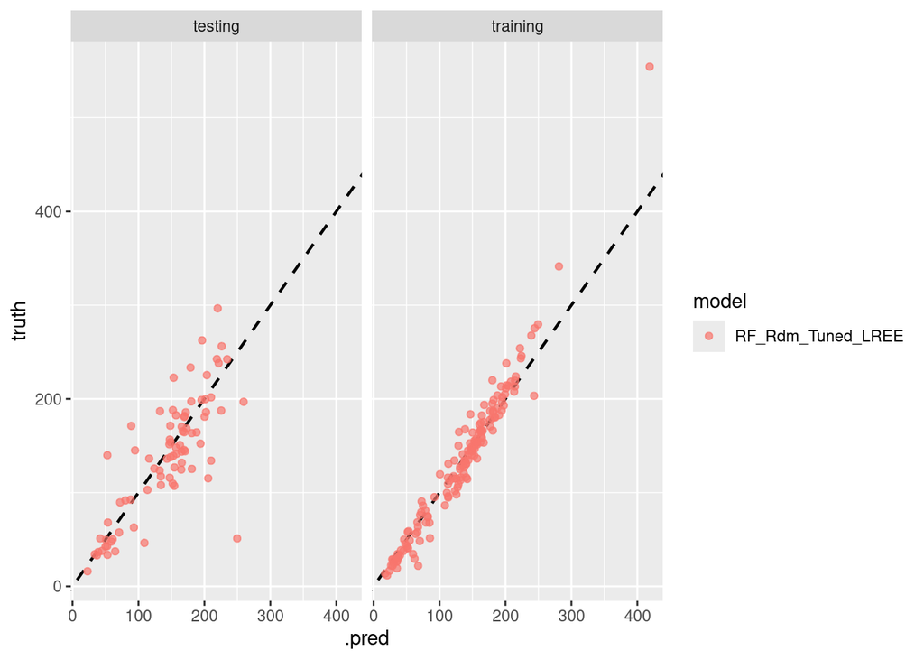

```r
results_lree_test %>%
  mutate(train = "testing") %>%
  bind_rows(results_lree_train %>%
              mutate(train = "training")) %>%
  ggplot(aes(.pred, truth, color = model)) +
  geom_abline(lty = 2, size = 0.75, linetype = "dashed") +
  geom_point(alpha = 0.7) +
  facet_wrap(~train)
```

### Random Forest Model: Option 2 (All elements from ME-4ACD81) - NO LONGER USED

#### Build the Model - NO LONGER USED

#### Evaluate the Model - NO LONGER USED

#### Prediction vs Actual Comparison - NO LONGER USED

### Random Forest Model: Option 3 (Elements with high variable importance)

Combination of elements with high variable importance from model 1, which are Tl, Pb, Sc, Cd, Zn, Cu.

#### Data Preparation

```r
# Filter the training and test datasets to include predictors and target variables only
DT_lree_train_fltr_3 <- DT_lree_train[,c("LREE","Tl", "Pb", "Sc", "Cd", "Zn", "Cu")]
DT_lree_test_fltr_3 <- DT_lree_test[,c("LREE","Tl", "Pb", "Sc", "Cd", "Zn", "Cu")]

# Create a cross-validation data for resampling purposes during hyperparameter tuning
set.seed(2022)
DT_lree_fltr_folds_3 <- vfold_cv(DT_lree_train_fltr_3, v = 5, repeats = 2)
```

#### Build the Model

```r
# Create a recipe for preprocessing
rf_lree_recipe_3 <- recipe(LREE ~ ., data = DT_lree_train_fltr_3)

# Create a workflow
rf_lree_tuned_workflow_3 <- workflow() %>%
  add_recipe(rf_lree_recipe_3) %>%
  add_model(rf_tuned_spec)

# Set-up the hyperparameter tuning
rf_lree_tuned_grid_3 <- grid_regular(
  mtry(range = c(1,6)),
  min_n(),
  trees(),
  levels = 5)

# Perform the hyperparameter tuning search
set.seed(2022)
rf_lree_random_tune_3 <- tune_grid(
  rf_lree_tuned_workflow_3,
  resamples = DT_lree_fltr_folds_3,
  grid = rf_lree_tuned_grid_3,
  metrics = metric_set(rmse, rsq, mae)
)

# Show the best configurations
show_best(rf_lree_random_tune_3, n = 3)
```

```
## # A tibble: 3 × 9
##    mtry trees min_n .metric .estimator  mean     n std_err .config
##   <int> <int> <int> <chr>   <chr>      <dbl> <int>   <dbl> <chr>
## 1     6  2000    11 rmse    standard    48.1    10    6.00 Preprocessor1_Model1…
## 2     4  1000    21 rmse    standard    48.1    10    6.26 Preprocessor1_Model0…
## 3     6   500    21 rmse    standard    48.1    10    6.06 Preprocessor1_Model0…
```

```r
# Fit the best model into the training set
set.seed(2022)
rf_lree_random_tuned_fit_3 <- finalize_workflow(rf_lree_tuned_workflow_3, select_best(rf_lree_random_tune_3)) %>%
    fit(DT_lree_train_fltr_3)
# Apply the trained recipe to the testing data
# 'bake()' will apply all recipe steps (e.g., imputation, normalization) to the testing dataset
DT_train_lree_fltr_prep_3 <- bake(prep(rf_lree_recipe_3), new_data = DT_lree_train_fltr_3)
DT_test_lree_fltr_prep_3 <- bake(prep(rf_lree_recipe_3), new_data = DT_lree_test_fltr_3)

# Make predictions on the preprocessed testing data
rf_lree_tr_rdm_tuned_pred_3 <- predict(rf_lree_random_tuned_fit_3, new_data = DT_lree_train_fltr_3)
rf_lree_ts_rdm_tuned_pred_3 <- predict(rf_lree_random_tuned_fit_3, new_data = DT_lree_test_fltr_3)
```

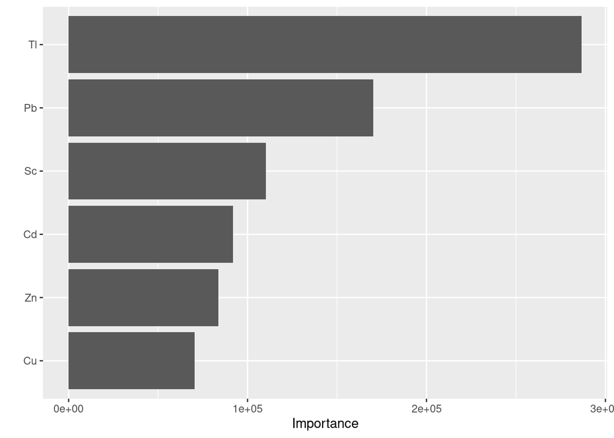

```r
# Plot variable importance
rf_lree_random_tuned_fit_3 %>%
  extract_fit_parsnip() %>%
  vip::vip()
```

#### Evaluate the Model

```r
# RF Tuned Results for all elements from ME-4ACD81
## Training set evaluation
results_train_rf_lree_rdm_tuned_3 <- rf_lree_tr_rdm_tuned_pred_3 %>%
  bind_cols(DT_lree_train_fltr_3) %>%
  dplyr::select(.pred, LREE) %>%
  rename(truth = LREE) %>%
  mutate(model = "RF_Rdm_Tuned_LREE_3")

## Test set evaluation
results_test_rf_lree_rdm_tuned_3 <- rf_lree_ts_rdm_tuned_pred_3 %>%
  bind_cols(DT_lree_test_fltr_3) %>%
  dplyr::select(.pred, LREE) %>%
  rename(truth = LREE) %>%
  mutate(model = "RF_Rdm_Tuned_LREE_3")

# Merge the results
## Training set
results_lree_train <- bind_rows(results_lree_train, results_train_rf_lree_rdm_tuned_3)

## Test set
results_lree_test <- bind_rows(results_lree_test, results_test_rf_lree_rdm_tuned_3)

# Show the evaluation metrics for every model
## Training set
results_lree_train %>%
  group_by(model) %>%
  summarise(RMSE = RMSE(.pred, truth),
            R_Square = R2_Score(.pred, truth),
            MAE = MAE(.pred, truth),
            MAPE = MAPE(.pred, truth))
```

```
## # A tibble: 2 × 5
##   model                RMSE R_Square   MAE  MAPE
##   <chr>               <dbl>    <dbl> <dbl> <dbl>
## 1 RF_Rdm_Tuned_LREE    18.6    0.937  12.0 0.135
## 2 RF_Rdm_Tuned_LREE_3  25.2    0.885  17.4 0.198
```

```r
## Test set
results_lree_test %>%
  group_by(model) %>%
  summarise(RMSE = RMSE(.pred, truth),
            R_Square = R2_Score(.pred, truth),
            MAE = MAE(.pred, truth),
            MAPE = MAPE(.pred, truth))
```

```
## # A tibble: 2 × 5
##   model                RMSE R_Square   MAE  MAPE
##   <chr>               <dbl>    <dbl> <dbl> <dbl>
## 1 RF_Rdm_Tuned_LREE    39.6    0.610  26.6 0.251
## 2 RF_Rdm_Tuned_LREE_3  40.5    0.593  27.7 0.267
```

#### Prediction vs Actual Comparison

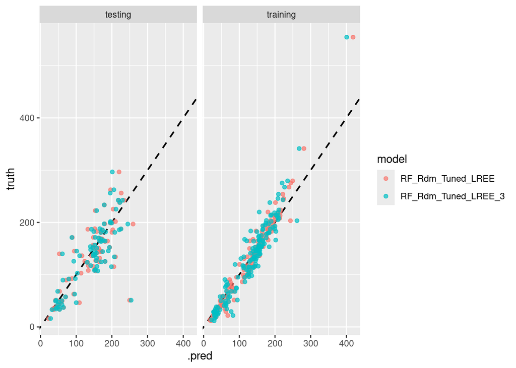

```r
results_lree_test %>%
  mutate(train = "testing") %>%
  bind_rows(results_lree_train %>%
              mutate(train = "training")) %>%
  ggplot(aes(.pred, truth, color = model)) +
  geom_abline(lty = 2, size = 0.75, linetype = "dashed") +
  geom_point(alpha = 0.7) +
  facet_wrap(~train)
```

### Random Forest Model: Option 4 (Elements with high correlation coefficient)

Combination of elements with above 0.5 correlation coefficient with LREE, which are Pb, Sc, Zn.

#### Data Preparation

```r
# Filter the training and test datasets to include predictors and target variables only
DT_lree_train_fltr_4 <- DT_lree_train[,c("LREE","Pb", "Sc", "Zn")]
DT_lree_test_fltr_4 <- DT_lree_test[,c("LREE","Pb", "Sc", "Zn")]

# Create a cross-validation data for resampling purposes during hyperparameter tuning
set.seed(2022)
DT_lree_fltr_folds_4 <- vfold_cv(DT_lree_train_fltr_4, v = 5, repeats = 2)
```

#### Build the Model

```r
# Create a recipe for preprocessing
rf_lree_recipe_4 <- recipe(LREE ~ ., data = DT_lree_train_fltr_4)

# Create a workflow
rf_lree_tuned_workflow_4 <- workflow() %>%
  add_recipe(rf_lree_recipe_4) %>%
  add_model(rf_tuned_spec)

# Set-up the hyperparameter tuning
rf_lree_tuned_grid_4 <- grid_regular(
  mtry(range = c(1,3)),
  min_n(),
  trees(),
  levels = 5)

# Perform the hyperparameter tuning search
set.seed(2022)
rf_lree_random_tune_4 <- tune_grid(
  rf_lree_tuned_workflow_4,
  resamples = DT_lree_fltr_folds_4,
  grid = rf_lree_tuned_grid_4,
  metrics = metric_set(rmse, rsq, mae)
)

# Show the best configurations
show_best(rf_lree_random_tune_4, n = 3)
```

```
## # A tibble: 3 × 9
##    mtry trees min_n .metric .estimator  mean     n std_err .config
##   <int> <int> <int> <chr>   <chr>      <dbl> <int>   <dbl> <chr>
## 1     1  2000    30 rmse    standard    54.3    10    7.55 Preprocessor1_Model70
## 2     1  1500    30 rmse    standard    54.4    10    7.52 Preprocessor1_Model55
## 3     1  1500    21 rmse    standard    54.5    10    7.51 Preprocessor1_Model52
```

```r
# Fit the best model into the training set
set.seed(2022)
rf_lree_random_tuned_fit_4 <- finalize_workflow(rf_lree_tuned_workflow_4, select_best(rf_lree_random_tune_4)) %>%
    fit(DT_lree_train_fltr_4)
# Apply the trained recipe to the testing data
# 'bake()' will apply all recipe steps (e.g., imputation, normalization) to the testing dataset
DT_train_lree_fltr_prep_4 <- bake(prep(rf_lree_recipe_4), new_data = DT_lree_train_fltr_4)
DT_test_lree_fltr_prep_4 <- bake(prep(rf_lree_recipe_4), new_data = DT_lree_test_fltr_4)

# Make predictions on the preprocessed testing data
rf_lree_tr_rdm_tuned_pred_4 <- predict(rf_lree_random_tuned_fit_4, new_data = DT_lree_train_fltr_4)
rf_lree_ts_rdm_tuned_pred_4 <- predict(rf_lree_random_tuned_fit_4, new_data = DT_lree_test_fltr_4)
```

#### Evaluate the Model

```r
# RF Tuned Results for all elements from ME-4ACD81
## Training set evaluation
results_train_rf_lree_rdm_tuned_4 <- rf_lree_tr_rdm_tuned_pred_4 %>%
  bind_cols(DT_lree_train_fltr_4) %>%
  dplyr::select(.pred, LREE) %>%
  rename(truth = LREE) %>%
  mutate(model = "RF_Rdm_Tuned_LREE_4")

## Test set evaluation
results_test_rf_lree_rdm_tuned_4 <- rf_lree_ts_rdm_tuned_pred_4 %>%
  bind_cols(DT_lree_test_fltr_4) %>%
  dplyr::select(.pred, LREE) %>%
  rename(truth = LREE) %>%
  mutate(model = "RF_Rdm_Tuned_LREE_4")

# Merge the results
## Training set
results_lree_train <- bind_rows(results_lree_train, results_train_rf_lree_rdm_tuned_4)

## Test set
results_lree_test <- bind_rows(results_lree_test, results_test_rf_lree_rdm_tuned_4)

# Show the evaluation metrics for every model
## Training set
results_lree_train %>%
  group_by(model) %>%
  summarise(RMSE = RMSE(.pred, truth),
            R_Square = R2_Score(.pred, truth),
            MAE = MAE(.pred, truth),
            MAPE = MAPE(.pred, truth))
```

```
## # A tibble: 3 × 5
##   model                RMSE R_Square   MAE  MAPE
##   <chr>               <dbl>    <dbl> <dbl> <dbl>
## 1 RF_Rdm_Tuned_LREE    18.6    0.937  12.0 0.135
## 2 RF_Rdm_Tuned_LREE_3  25.2    0.885  17.4 0.198
## 3 RF_Rdm_Tuned_LREE_4  42.4    0.676  28.0 0.352
```

```r
## Test set
results_lree_test %>%
  group_by(model) %>%
  summarise(RMSE = RMSE(.pred, truth),
            R_Square = R2_Score(.pred, truth),
            MAE = MAE(.pred, truth),
            MAPE = MAPE(.pred, truth))
```

```
## # A tibble: 3 × 5
##   model                RMSE R_Square   MAE  MAPE
##   <chr>               <dbl>    <dbl> <dbl> <dbl>
## 1 RF_Rdm_Tuned_LREE    39.6    0.610  26.6 0.251
## 2 RF_Rdm_Tuned_LREE_3  40.5    0.593  27.7 0.267
## 3 RF_Rdm_Tuned_LREE_4  38.4    0.633  29.6 0.314
```

#### Prediction vs Actual Comparison

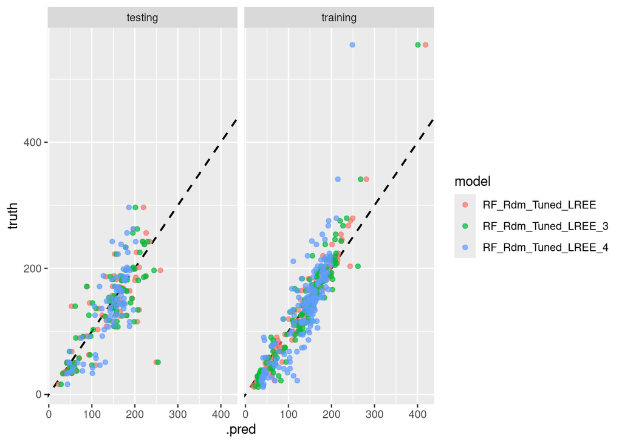

```r
results_lree_test %>%
  mutate(train = "testing") %>%
  bind_rows(results_lree_train %>%
              mutate(train = "training")) %>%
  ggplot(aes(.pred, truth, color = model)) +
  geom_abline(lty = 2, size = 0.75, linetype = "dashed") +
  geom_point(alpha = 0.7) +
  facet_wrap(~train)
```

Combination of elements with above 0.5 correlation coefficient with LREE, which are Pb, Sc, Zn. This is the only model being performed with XGBoost considering this combination of predictors produce the best model from the Random Forest model series.

#### Data Preparation

Data preparation is not needed for this model, because this model use the same data as what “Random Forest Option 4” use.

#### Build the Model

```r
# Define the recipe for XGBoost
xgb_recipe_lree <- recipe(LREE ~ ., data = DT_lree_train_fltr_4)

# XGB tune workflow
xgb_tuned_workflow_lree <- workflow() %>%
  add_model(xgb_tuned_spec) %>%
  add_recipe(xgb_recipe_lree)


# Set-up the hyperparameter tuning
xgboost_params_lree <- parameters(
  tree_depth(),
  learn_rate(),
  loss_reduction(),
  min_n(),
  sample_size = sample_prop(),
  finalize(mtry(), DT_lree_train_fltr_4))

xgboost_grid_lree <-
  dials::grid_space_filling(
    xgboost_params_lree,
    size = 20
  )


# Tune the model
set.seed(2022)
xgb_tune_lree <- xgb_tuned_workflow_lree %>%
  tune_grid(resamples = DT_lree_fltr_folds_4,
            grid = xgboost_grid_lree,
            metrics = metric_set(rmse, rsq, mae),
            control = control_grid(save_pred = TRUE))
```

```
## → A | warning: A correlation computation is required, but `estimate` is constant and has 0
##                standard deviation, resulting in a divide by 0 error. `NA` will be returned.
```

[output not shown]

```r
# Show the best configurations
show_best(xgb_tune_lree, n = 5, metric = "rmse")
```

```
## # A tibble: 5 × 12
##    mtry min_n tree_depth learn_rate loss_reduction sample_size .metric
##   <int> <int>      <int>      <dbl>          <dbl>       <dbl> <chr>
## 1     4    34          8    0.00127       1.73e- 6       0.858 rmse
## 2     3    20          2    0.00379       4.03e-10       0.289 rmse
## 3     2     8          3    0.0113        4.83e- 1       0.479 rmse
## 4     2    12         13    0.1           2.64e- 8       0.432 rmse
## 5     2    38          6    0.0336        2.98e- 2       0.337 rmse
## # ℹ 5 more variables: .estimator <chr>, mean <dbl>, n <int>, std_err <dbl>,
## #   .config <chr>
```

```r
# Fit the best model into the training set
set.seed(2022)
xgb_tuned_fit_lree <- finalize_workflow(xgb_tuned_workflow_lree, select_best(xgb_tune_lree, metric = "rmse")) %>%
    fit(DT_lree_train_fltr_4)

# Make predictions on the test set
xgb_lree_train_predictions <- predict(xgb_tuned_fit_lree, new_data = DT_lree_train_fltr_4)

# Make predictions on the test set
xgb_lree_test_predictions <- predict(xgb_tuned_fit_lree, new_data = DT_lree_test_fltr_4)
```

#### Evaluate the Model

```r
# Evaluate performance on training data
xgb_train_results_lree <- xgb_lree_train_predictions %>%
  bind_cols(DT_lree_train_fltr_4) %>%
  dplyr::select(.pred, LREE) %>%
  rename(truth = LREE) %>%
  mutate(model = "XGBoost_Tuned_LREE")

# Evaluate performance on test data
xgb_test_results_lree <- xgb_lree_test_predictions %>%
  bind_cols(DT_lree_test_fltr_4) %>%
  dplyr::select(.pred, LREE) %>%
  rename(truth = LREE) %>%
  mutate(model = "XGBoost_Tuned_LREE")

# Merge the results
## Training set
results_lree_train <- bind_rows(results_lree_train, xgb_train_results_lree)

## Test set
results_lree_test <- bind_rows(results_lree_test, xgb_test_results_lree)

# Saving the data into .RDS format for final report & presentation purpose
saveRDS(results_lree_test, './Final_report/Final_report_files/lree_results_test.rds')

# Show the evaluation metrics for every model
## Training set
results_lree_train %>%
  group_by(model) %>%
  summarise(RMSE = RMSE(.pred, truth),
            R_Square = R2_Score(.pred, truth),
            MAE = MAE(.pred, truth),
            MAPE = MAPE(.pred, truth))
```

```
## # A tibble: 4 × 5
##   model                RMSE R_Square   MAE  MAPE
##   <chr>               <dbl>    <dbl> <dbl> <dbl>
## 1 RF_Rdm_Tuned_LREE    18.6    0.937  12.0 0.135
## 2 RF_Rdm_Tuned_LREE_3  25.2    0.885  17.4 0.198
## 3 RF_Rdm_Tuned_LREE_4  42.4    0.676  28.0 0.352
## 4 XGBoost_Tuned_LREE   54.4    0.466  34.4 0.375
```

```r
## Test set
results_lree_test %>%
  group_by(model) %>%
  summarise(RMSE = RMSE(.pred, truth),
            R_Square = R2_Score(.pred, truth),
            MAE = MAE(.pred, truth),
            MAPE = MAPE(.pred, truth))
```

```
## # A tibble: 4 × 5
##   model                RMSE R_Square   MAE  MAPE
##   <chr>               <dbl>    <dbl> <dbl> <dbl>
## 1 RF_Rdm_Tuned_LREE    39.6    0.610  26.6 0.251
## 2 RF_Rdm_Tuned_LREE_3  40.5    0.593  27.7 0.267
## 3 RF_Rdm_Tuned_LREE_4  38.4    0.633  29.6 0.314
## 4 XGBoost_Tuned_LREE   41.7    0.568  31.1 0.274
```

#### Prediction vs Actual Comparison

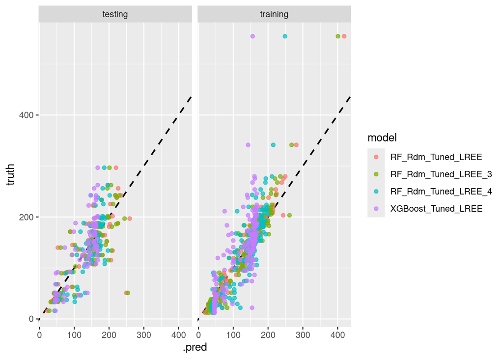

```r
results_lree_test %>%
  mutate(train = "testing") %>%
  bind_rows(results_lree_train %>%
              mutate(train = "training")) %>%
  ggplot(aes(.pred, truth, color = model)) +
  geom_abline(lty = 2, size = 0.75, linetype = "dashed") +
  geom_point(alpha = 0.7) +
  facet_wrap(~train)
```

### Selecting the best Model

#### Model Comparison

```r
# Display all model
results_lree_test_df <- results_lree_test %>%
  group_by(model) %>%
  summarise(RMSE = RMSE(.pred, truth),
            R_Square = R2_Score(.pred, truth),
            MAE = MAE(.pred, truth),
            MAPE = MAPE(.pred, truth)) %>%
  filter(model %in% c("RF_Rdm_Tuned_LREE","RF_Rdm_Tuned_LREE_3","RF_Rdm_Tuned_LREE_4", "XGBoost_Tuned_LREE")) %>%
  mutate(method = case_when(model == "RF_Rdm_Tuned_LREE" ~ "Random Forest",
                                    # model == "RF_Rdm_Tuned_LREE_2" ~ "Random Forest",
                                    model == "RF_Rdm_Tuned_LREE_3" ~ "Random Forest",
                                    model == "RF_Rdm_Tuned_LREE_4" ~ "Random Forest",
                                    model == "XGBoost_Tuned_LREE" ~ "XGBoost")) %>%
  mutate(model_scenarios = case_when(model == "RF_Rdm_Tuned_LREE" ~ "Default tuned",
                                    # model == "RF_Rdm_Tuned_LREE_2" ~ "Project-stratified",
                                    model == "RF_Rdm_Tuned_LREE_3" ~ "Elements with high variable importance",
                                    model == "RF_Rdm_Tuned_LREE_4" ~ "Elements with correlation coefficient above 0.5",
                                    model == "XGBoost_Tuned_LREE" ~ "Elements with correlation coefficient above 0.5")) %>%
  mutate(elements = case_when(model == "RF_Rdm_Tuned_LREE" ~ "All elements",
                                    # model == "RF_Rdm_Tuned_LREE_2" ~ "All elements",
                                    model == "RF_Rdm_Tuned_LREE_3" ~ "Tl, Pb, Sc, Cd, Zn, Cu",
                                    model == "RF_Rdm_Tuned_LREE_4" ~ "Pb, Sc, Zn",
                                    model == "XGBoost_Tuned_LREE" ~ "Pb, Sc, Zn")) %>%
  mutate(target_var = "LREE") %>%
  select(target_var, method, model_scenarios, elements, RMSE, MAE, MAPE, R_Square)

# Saving the data into .RDS format for final report purpose
saveRDS(results_lree_test_df, './Final_report/Final_report_files/results_lree_test_df.rds')
```

#### Prediction vs Actual Comparison of Best Model

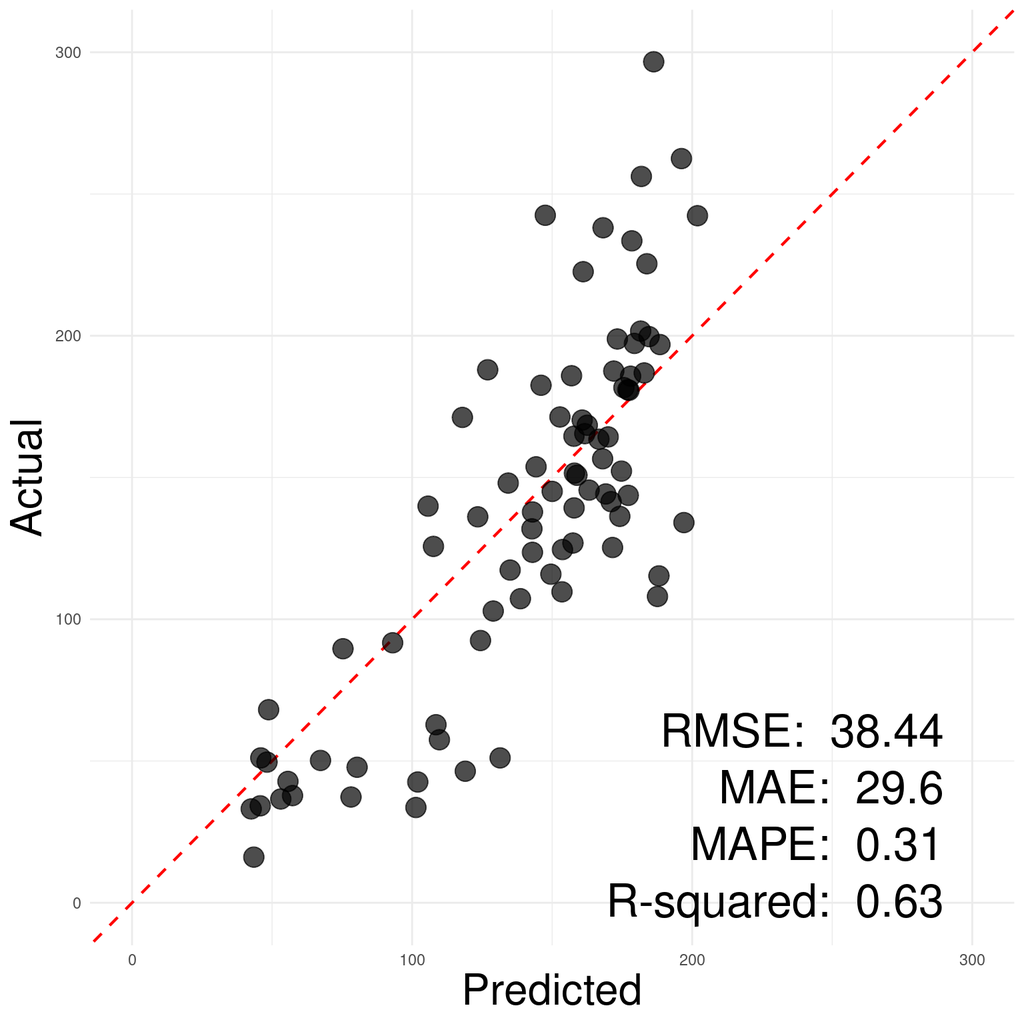

Actual vs Prediction Results

```r
# Getting metrics values
lree_rmse_value <- results_lree_test_df[3,5]
lree_rsq_value <- results_lree_test_df[3,8]
lree_mae_value <- results_lree_test_df[3,6]
lree_mape_value <- results_lree_test_df[3,7]

results_lree_test_best <- results_lree_test %>%
  filter(model %in% c("RF_Rdm_Tuned_LREE_4")) %>%
  ggplot(aes(.pred, truth)) +
  geom_abline(lty = 2, linewidth = 0.75, linetype = "dashed", colour='red') +
  geom_point(alpha = 0.7, colour = "black", size = 5) +
  xlim(c(0,300)) +
  ylim(c(0,300)) +
  xlab("Predicted") +
  ylab("Actual") +
  # facet_wrap(~train) +
  theme_minimal() +
  theme(axis.title.x = element_text(size = 24),            # Increase X-axis title size
        axis.title.y = element_text(size = 24)) +          # Increase Y-axis title size
  # Annotate the plot with the metrics
  annotate("text", x = 290, y = 61, label = paste("RMSE: ", round(lree_rmse_value, 2)), size = 9, hjust = 1) +
  annotate("text", x = 290, y = 41, label = paste("MAE: ", round(lree_mae_value, 2)), size = 9, hjust = 1) +
  annotate("text", x = 290, y = 21, label = paste("MAPE: ", round(lree_mape_value, 2)), size = 9, hjust = 1) +
  annotate("text", x = 290, y = 1, label = paste("R-squared: ", round(lree_rsq_value, 2)), size = 9, hjust = 1)

print(results_lree_test_best)
```

```r
# Save the plot to a .png file
ggsave("./Final_report/Final_report_files/figure-latex/results_lree_test_best.png", plot = results_lree_test_best, width = 8, height = 8, dpi = 300)
```